# Covid-19 in The United States

2/13/2022

## Introduction

The Covid-19 pandemic has been impacting the United States and the World for two years with over 900,000 people having died in the U.S. alone. Some Covid-19 data will explored and analyzed to illustrate this impact and answer a series of common questions:  
- Is Covid-19 comparable to the flu?  
- In general, how does Covid-19 affect different age and gender groups?  
- Should we still be concerned about Covid-19 in Arizona?

## Datasets

The publicly available Provisional_COVID-19_Deaths_by_Sex_and_Age data set will be used and is provided by the National Center for Health Statstics from the CDC website: https://data.cdc.gov/NCHS/Provisional-COVID-19-Deaths-by-Sex-and-Age/9bhg-hcku  
The United States COVID-19 Cases and Deaths by State over Time data set will also be used and is provided by the CDC Case Task Force from the website: https://data.cdc.gov/Case-Surveillance/United-States-COVID-19-Cases-and-Deaths-by-State-o/9mfq-cb36

## Data Cleaning

- Because of delays or absence in reporting, some of the mortality columns for both datasets have N/A values, It will be assumed that any deaths during this reporting period would be included in the next, so all N/A values in the mortality columns will be converted to zeros.
- The first data set is difficult to manipulate with the current column titles so those will be modified as well.

## Results

## Is Covid-19 comparable to the flu?

- With reporting from the beginning of the Covid-19 Pandemic to today, there have been a total of 10,119 Influenza deaths and 880,487 Covid-19 deaths.

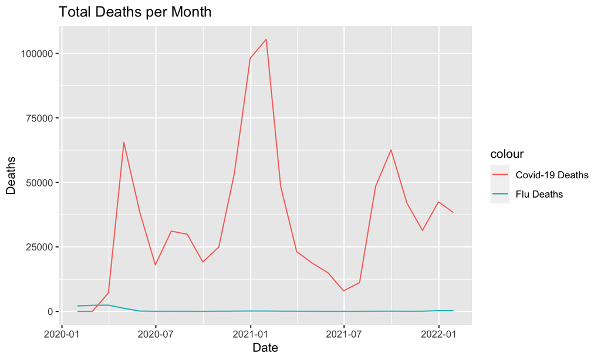

## Is Covid-19 comparable to the flu?

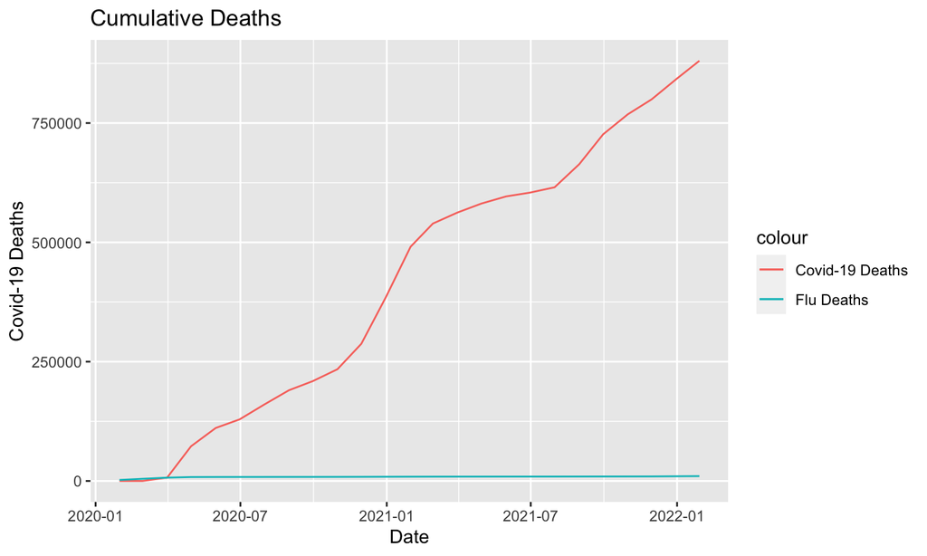

## In general, how does Covid-19 affect different age and gender groups?

### Age

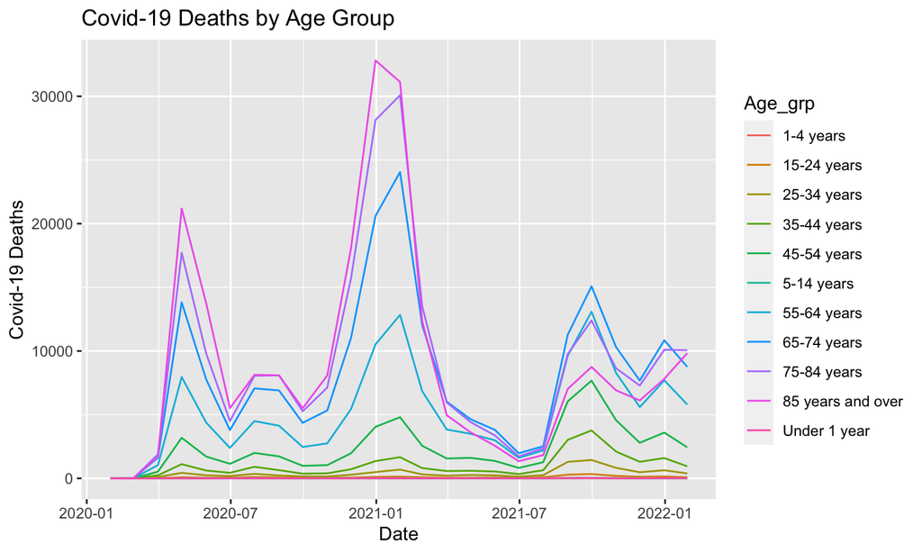

## In general, how does Covid-19 affect different age and gender groups?

### Age

```
##              Age_grp C19_deaths
## 1          1-4 years         87
## 11      Under 1 year        200
## 6         5-14 years        235
## 2        15-24 years       2301
## 3        25-34 years       9789
## 4        35-44 years      24673
## 5        45-54 years      59422
## 7        55-64 years     129476
## 8        65-74 years     201292
## 9        75-84 years     225952
## 10 85 years and over     227060
```

## Gender

```
##  Female deaths:  393445
##  Male deaths:  487042
##  Difference:  93597
```

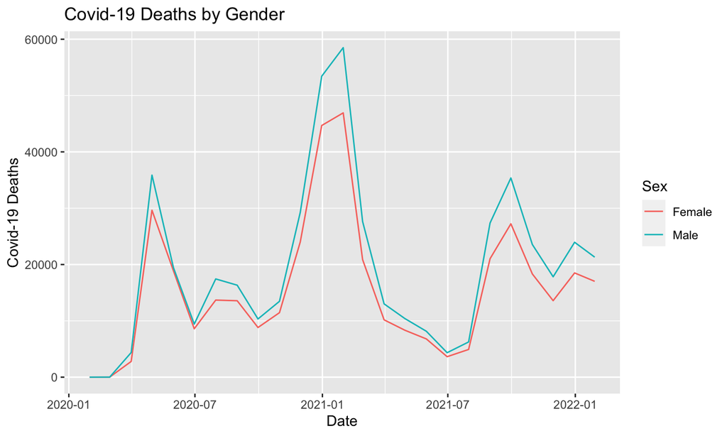

## Gender

- To test if this difference is statistically significant, a students t-test was preformed.

\(H_{0}\) : The population means of Covid-19 deaths are the same for males and females  
\(H_{a}\) : The population means of Covid-19 deaths are different for males and females

```
## p value =  0.3347044   Test statistic =  -0.9749045
```

- The resulting p value was \(0.3347\) and the t value was \(-0.9749\). Therefore, we cannot reject the null hypothesis that the means are the same and there is not a statistically significant difference between them.

## Should we still be concerned about Covid-19 in Arizona?

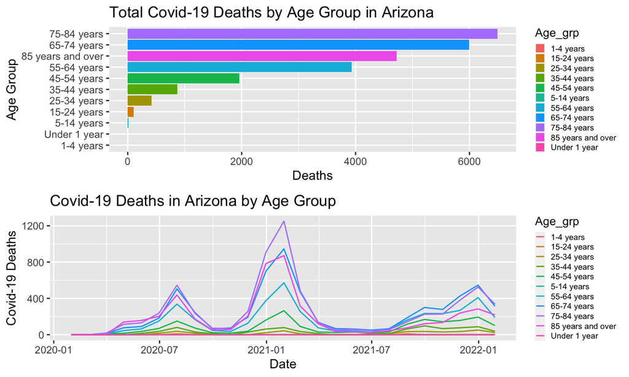

## Should we still be concerned about Covid-19 in Arizona?

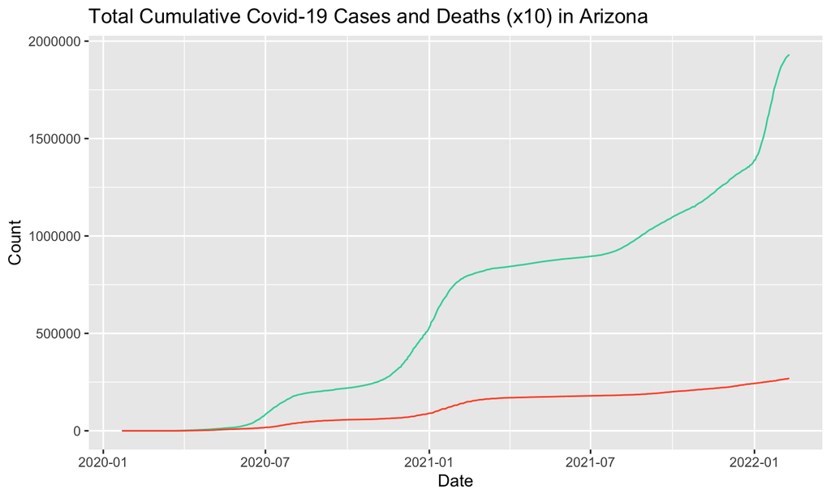

Note: Deaths were increased by a factor of ten for the purpose of better illustrating the trend.

## Conclusion

By analyzing the two CDC data sets, we have ascertained answers to our questions:

- Is Covid-19 comparable to the flu?  
  Covid-19 is not comparable to the flu.
- In general, how does Covid-19 affect different age and gender groups?  
  Covid-19 affects age groups differently, with older age groups more likely to die than younger ones. However, this is not the case for children under 1 year.
- Should we still be concerned about Covid-19 in Arizona?  
  The Covid-19 Pandemic has and still is affecting the Country and the Arizona community